# Lab 5

Blue Team: Matt Lawson, Bing Mitchell, Nick Zimmerman, Brandon Bowen

## Team Plots

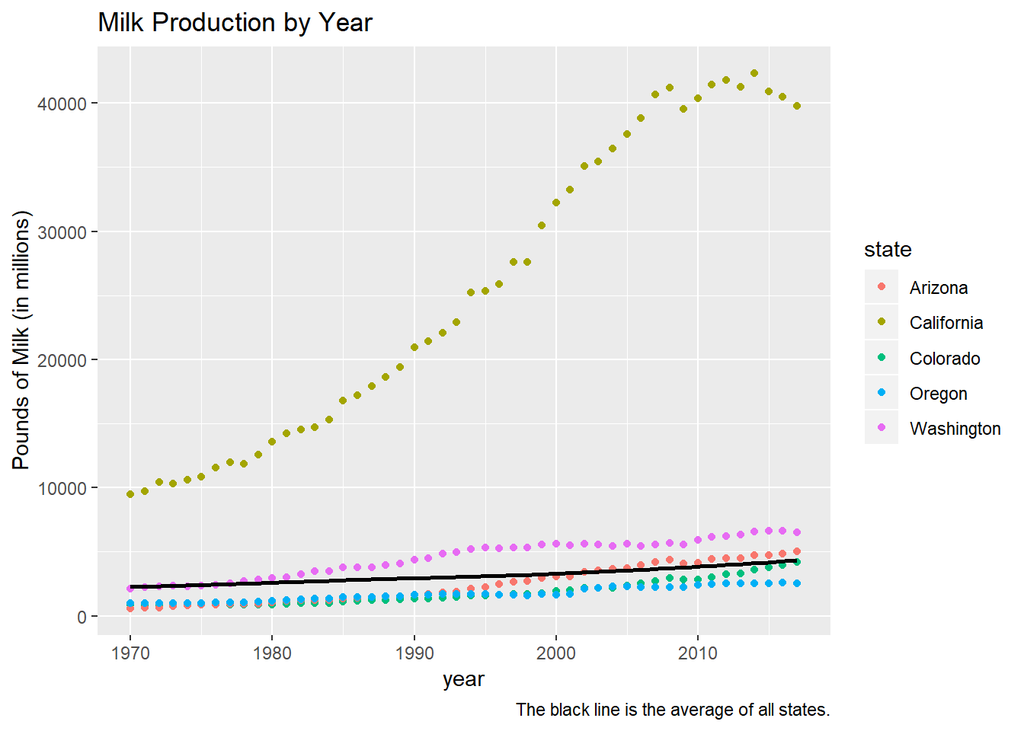

```r
milksub <- milk %>%
  filter(state %in% c('California','Colorado','Oregon','Washington','Arizona', 'All States')) %>% select(state, year, milk_million)

averageByYear <- milk %>%
  group_by(year) %>%
  summarize(average=mean(milk_million))

ggplot(data = milksub) +
  geom_point(mapping = aes(x= year, y = milk_million, color =state)) +
  geom_smooth(data=averageByYear, aes(x=year, y=average), se=F, color="black") +
  labs(title="Milk Production by Year", y="Pounds of Milk (in millions)", caption="The black line is the average of all states.")
```

### Plot information

This plot displays the milk produced by a few select states, as well as the U.S. average. The average is substantialy lower than California, a top milk producer, but prety close to the other four states. This pushes us to think that most milk in the United States is produced by a few states, while the majoroity of states produce very little. This could be due to aviability of farmland in each state or how fetile the land is.

### Year with the most milk produced

```r
mostMilk <- milk %>%
  group_by(year) %>%
  summarize(average=mean(milk_million)) %>%
  arrange(desc(average)) %>%
  top_n(1, year)

kable(mostMilk)
```

| year | average |
| --- | --- |
| 2017 | 4309.32 |

The United States produced the most milk in 2017.

### Year with the least milk produced

```r
mostMilk <- milk %>%
  group_by(year) %>%
  summarize(average=mean(milk_million)) %>%
  arrange(average) %>%
  top_n(-1, year)

kable(mostMilk)
```

| year | average |
| --- | --- |
| 1970 | 2340.14 |

The United States produced the least amount of milk in 1970.

### Top 5 Producers of Milk in 2017

```r
mostMilk <- milk %>%
  filter(year==2017) %>%
  arrange(desc(milk_million)) %>%
  top_n(5, milk_million) %>%
  select(state)
kable(mostMilk)
```

| state |
| --- |
| California |
| Wisconsin |
| New York |
| Idaho |
| Texas |

### Bottom 5 Producers of Milk in 2017

```r
leastMilk <- milk %>%
  filter(year==2017) %>%
  arrange(milk_million) %>%
  top_n(-5, milk_million) %>%
  select(state)
kable(leastMilk)
```

| state |
| --- |
| Alaska |
| Rhode Island |
| Hawaii |
| Arkansas |
| Alabama |

## Individual Plots

### Bing

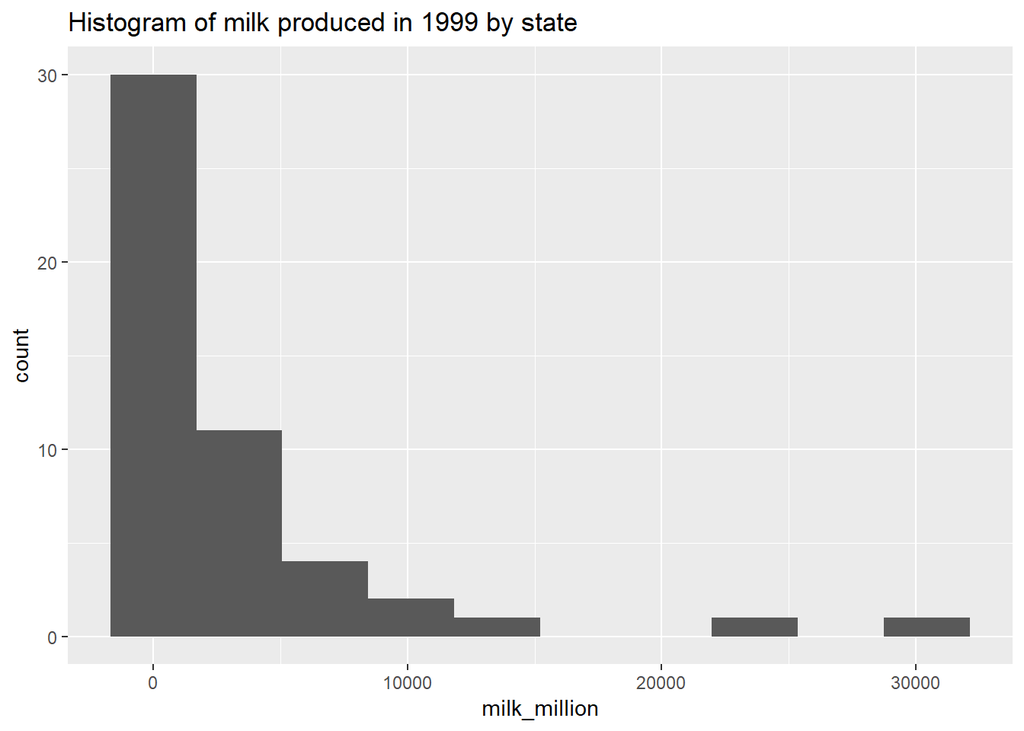

```r
milk1998 <- milk %>%
  filter(year == 1999)

ggplot(data = milk1998, aes(x = milk_million)) + geom_histogram(bins = 10) + ggtitle('Histogram of milk produced in 1999 by state')
```

```r
byState <- milk %>%
  select(state, year, milk_million) %>%
  group_by(state) %>%
  filter(year==1999) %>%
  arrange(milk_million)

minState = byState$state[byState$milk_million == min(byState$milk_million)]
maxState = byState$state[byState$milk_million == max(byState$milk_million)]
medianState = byState$state[byState$milk_million == quantile(byState$milk_million, 0.5, type=1)]

info <- milk %>%
  group_by(year) %>%
  filter(year==1999) %>%
  summarise(mean = mean(milk_million), median=medianState, maximum=maxState, minimum=minState)

kable(info)
```

| year | mean | median | maximum | minimum |
| --- | --- | --- | --- | --- |
| 1999 | 3251.8 | Tennessee | California | Alaska |

### Matt

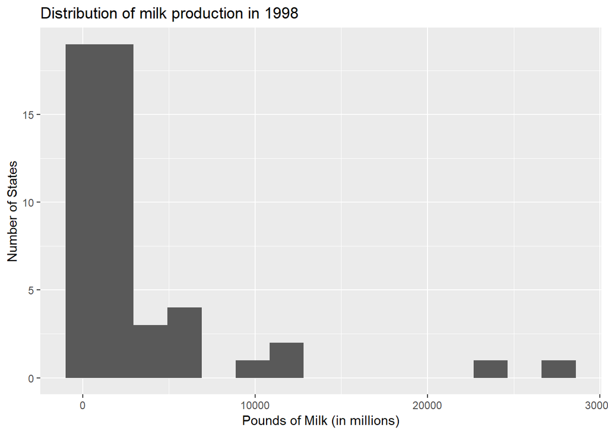

```r
milk %>%
  filter(year==1998) %>%
  ggplot(aes(x=milk_million)) +
  geom_histogram(bins=15) +
  ggtitle("Distribution of milk production in 1998") +
  labs(x="Pounds of Milk (in millions)", y="Number of States")
```

```r
byState <- milk %>%
  select(state, year, milk_million) %>%
  group_by(state) %>%
  filter(year==1998) %>%
  arrange(milk_million)

minState = byState$state[byState$milk_million == min(byState$milk_million)]
maxState = byState$state[byState$milk_million == max(byState$milk_million)]
medianState = byState$state[byState$milk_million == quantile(byState$milk_million, 0.5, type=1)]

info <- milk %>%
  group_by(year) %>%
  filter(year==1998) %>%
  summarise(mean = mean(milk_million), median=medianState, maximum=maxState, minimum=minState)

kable(info)
```

| year | mean | median | maximum | minimum |
| --- | --- | --- | --- | --- |
| 1998 | 3145.22 | South Dakota | California | Alaska |

### Brandon

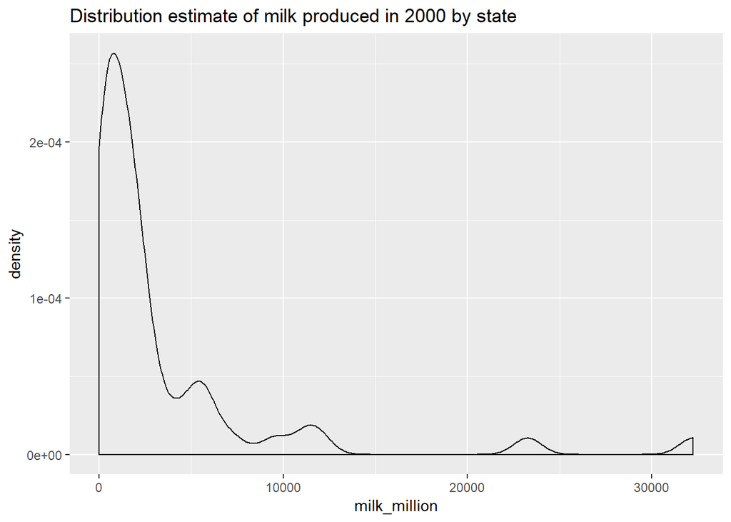

```r
milk %>%
  filter(year == 2000) %>%
ggplot(aes(x = milk_million)) +
  geom_density() +
  ggtitle('Distribution estimate of milk produced in 2000 by state')
```

```r
byState <- milk %>%
  select(state, year, milk_million) %>%
  group_by(state) %>%
  filter(year==2000) %>%
  arrange(milk_million)

minState = byState$state[byState$milk_million == min(byState$milk_million)]
maxState = byState$state[byState$milk_million == max(byState$milk_million)]
medianState = byState$state[byState$milk_million == quantile(byState$milk_million, 0.5, type=1)]

info <- milk %>%
  group_by(year) %>%
  filter(year==2000) %>%
  summarise(mean = mean(milk_million), median=medianState, maximum=maxState, minimum=minState)

kable(info)
```

| year | mean | median | maximum | minimum |
| --- | --- | --- | --- | --- |
| 2000 | 3347.84 | Georgia | California | Alaska |

### Nick

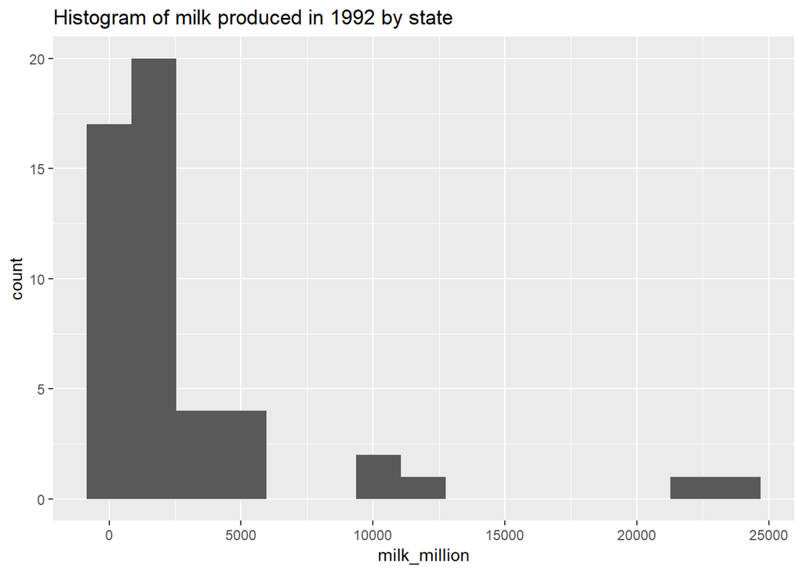

```r
ggplot(data = filter(milk, year == 1992), aes(x = milk_million))+
  geom_histogram(bins = 15)+
  ggtitle("Histogram of milk produced in 1992 by state")
```

```r
byState <- milk %>%
  select(state, year, milk_million) %>%
  group_by(state) %>%
  filter(year==1992) %>%
  arrange(milk_million)

minState = byState$state[byState$milk_million == min(byState$milk_million)]
maxState = byState$state[byState$milk_million == max(byState$milk_million)]
medianState = byState$state[byState$milk_million == quantile(byState$milk_million, 0.5, type=1)]

info <- milk %>%
  group_by(year) %>%
  filter(year==1992) %>%
  summarise(mean = mean(milk_million), median=medianState, maximum=maxState, minimum=minState)

kable(info)
```

| year | mean | median | maximum | minimum |
| --- | --- | --- | --- | --- |
| 1992 | 3017.68 | Maryland | Wisconsin | Alaska |

### Team Report

We found that having a good understanding of the data before manipulating it was helpful. Then, creating new variables `like milk_million` is super easy. Also, narrowing down the data with `filter` and `select` made it a lot easier to comprehend.

### contribution

Matt worked on his personal plots,the most produced/least produced years, and the 2017 reports.

Brandon worked on his personal plots, answered the signifigance of the team plot and typed the team report.

Bing worked on his prsonal plot and the team plot, also the 2017 reports.

Nick worked on his personal plot and helped with the team plot signifigance and the the team report.